# Reproducible Research - Assignment Week 2

## Personal Movement Analysis

This document shows the analysis over two months of data which include the number of steps taken in 5 minute intervals each day which have been collected with a device such as a [Fitbit](http://www.fitbit.com/), [Nike Fuelband](http://www.nike.com/us/en_us/c/nikeplus-fuelband), or [Jawbone Up](https://jawbone.com/up).

These data have been collected during the months of October and November 2012 from an anonymous individual.

The variables included in this dataset:

- steps: Number of steps taking in a 5-minute interval (missing values are coded as NA).
- date: The date on which the measurement was taken in YYYY-MM-DD format.
- interval: Identifier for the 5-minute interval in which measurement was taken.

### Loading and preprocessing the data

**1.- Load the data**

```r
if (file.exists("activity.zip")) {
        unzip(zipfile="activity.zip")
        activity <- read.csv("activity.csv")
}
```

### What is mean total number of steps taken per day?

Missing values will be ignored for this question.

**1.- Calculate the total number of steps taken per day.**

```r
steps_day <- aggregate(activity$steps, list(activity$date), sum)
```

**2.- Make a histogram of the total number of steps taken each day.**

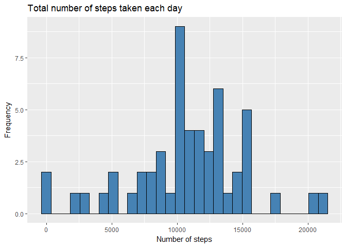

```r
library(ggplot2)

names(steps_day) <- c("date", "steps")
qplot(steps, data=steps_day, geom="histogram",
      fill=I("steelblue"), col=I("black"),
      xlab="Number of steps", ylab="Frequency",
      main="Total number of steps taken each day")
```

**3.- Calculate and report the mean and median of the total number of steps taken per day.**

```r
steps_mean <- mean(steps_day$steps, na.rm=TRUE)
sprintf("Mean: %f", steps_mean)
```

```
## [1] "Mean: 10766.188679"
```

```r
steps_median <- median(steps_day$steps, na.rm=TRUE)
sprintf("Median: %f", steps_median)
```

```
## [1] "Median: 10765.000000"
```

### What is the average daily activity pattern?

**1.- Make a time series plot (i.e. type = “l”) of the 5-minute interval (x-axis) and the average number of steps taken, averaged across all days (y-axis).**

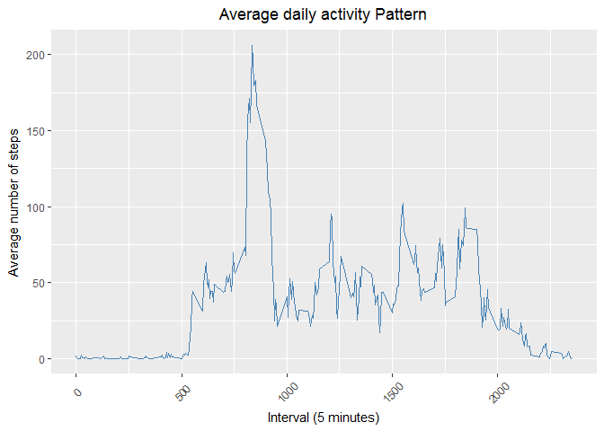

```r
steps_day_mean <- aggregate(activity$steps, list(activity$interval), mean, na.rm=TRUE)
names(steps_day_mean) <- c("interval", "steps")

steps_ok <- !is.na(steps_day_mean$steps)
steps_mean_ok <- steps_day_mean[steps_ok,]

ggplot(steps_mean_ok, aes(interval,steps)) +
        geom_line(col="steelblue") +
        labs(title = "Average daily activity Pattern") +
        labs(x = "Interval (5 minutes)", y = "Average number of steps") +
        theme(axis.text.x=element_text(angle=45,hjust=0.5,vjust=0.5),
              plot.title = element_text(hjust=0.5))
```

**2.- Which 5-minute interval, on average across all the days in the dataset, contains the maximum number of steps?**

```r
max_interval <- steps_mean_ok[which.max(steps_mean_ok$steps),1]
sprintf("Interval with the maximum number of steps: %d", max_interval)
```

```
## [1] "Interval with the maximum number of steps: 835"
```

### Imputing missing values

Note that there are a number of days/intervals where there are missing values (coded as NA). The presence of missing days may introduce bias into some calculations or summaries of the data.

**1.- Calculate and report the total number of missing values in the dataset (i.e. the total number of rows with NAs).**

```r
missing <- sum(is.na(activity$steps))
sprintf("Number of missing values (NA): %i", missing)
```

```
## [1] "Number of missing values (NA): 2304"
```

**2.- Devise a strategy for filling in all of the missing values in the dataset.**

The strategy is to add create a new dataset from the original one:

- A new column will be added, mean_day. This column will be filled with the mean for each day.
- In case of days with no data (NAs for all intervals in the day), the mean of all days will be imputed in the new column.
- Finally the days with NA will be filled with the corresponding value in the new column mean_day.

**3.- Create a new dataset that is equal to the original dataset but with the missing data filled in.**

```r
## Add new column 'mean_day' with mean steps for the day
library(dplyr)
activity2 <- activity %>%
                group_by(date) %>%
                mutate(mean_day = mean(steps, na.omit=TRUE))

## Fill the missing values in the new column 'mean_day'
## with the mean for all days
nas_mean_day <- is.na(activity2$mean_day)
activity2[nas_mean_day,"mean_day"] <- mean(activity2$steps, na.rm=TRUE)

## Finally, fill the missing values in 'steps' with the values
## in new column mean_day
nas_steps <- is.na(activity2$steps)
activity2[nas_steps,"steps"] <- activity2[nas_steps,"mean_day"]
```

**4.- Make a histogram of the total number of steps taken each day.**

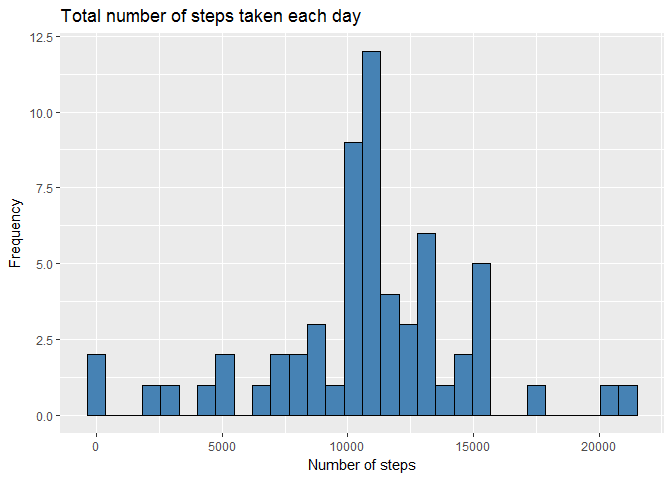

```r
steps_day_noNAs <- aggregate(activity2$steps, list(activity$date), sum)
names(steps_day_noNAs) <- c("date", "steps")
qplot(steps, data=steps_day_noNAs, geom="histogram",
      fill=I("steelblue"), col=I("black"),
      xlab="Number of steps", ylab="Frequency",
      main="Total number of steps taken each day")
```

**5.- Calculate and report the mean and median total number of steps taken per day.**

```r
steps_mean_noNAs <- mean(steps_day_noNAs$steps, na.rm=TRUE)
sprintf("Mean: %f", steps_mean_noNAs)
```

```
## [1] "Mean: 10766.188679"
```

```r
steps_median_noNAs <- median(steps_day_noNAs$steps, na.rm=TRUE)
sprintf("Median: %f", steps_median_noNAs)
```

```
## [1] "Median: 10766.188679"
```

**6.- Do these values differ from the estimates from the first part of the assignment? What is the impact of imputing missing data on the estimates of the total daily number of steps?**

The distribution remains more or less equal.

The mean stays equal and the median matches the mean which seems reasonable as we have used the mean to fill missing values for the days with no data.

The impacts are minimum.

### Are there differences in activity patterns between weekdays and weekends?

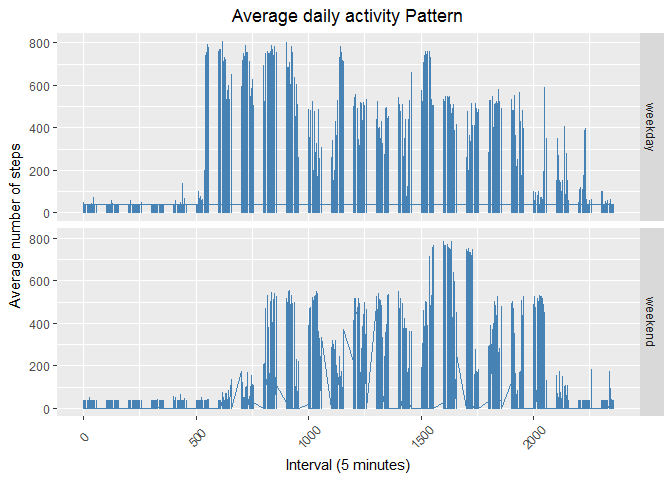

```r
library(lubridate)

activity2_day_mean <- aggregate(steps ~ interval + date, data=activity2, mean)

weekday <- c("Mon", "Tues", "Wed", "Thurs", "Fri")
activity2_day_mean$date <- as.Date(activity2_day_mean$date)

activity2_day_mean$wday <- as.factor(ifelse (wday(activity2_day_mean$date, label = TRUE) %in% weekday,
                          "weekday", "weekend"))

ggplot(activity2_day_mean, aes(interval,steps)) +
        geom_line(col="steelblue") +
        labs(title = "Average daily activity Pattern") +
        labs(x = "Interval (5 minutes)", y = "Average number of steps") +
        facet_grid(wday~.) +
        theme(axis.text.x=element_text(angle=45,hjust=0.5,vjust=0.5),
              plot.title = element_text(hjust = 0.5))
```